# Group_8_Analysis

Which properties of films influence whether they are rated by IMDB as greater than 7 or not?

```r
# Load required packages for data analysis and visualisation
library(ggplot2)   # Data visualisation
library(tidyverse) # Data manipulation and general workflow tools
library(gt)        # Table formatting
library(broom)     # Convert model outputs into tidy data frames
library(knitr)     # Create formatted tables in the report
library(dplyr)     # Data manipulation functions
library(tibble)    # Enhanced data frame tools
```

# 1 Introduction

This study investigates which film characteristics influence whether a film receives an IMDB rating greater than 7. IMDB ratings are widely used as an indicator of audience perception and overall film quality, as they are based on a large number of user evaluations.

Understanding which characteristics are associated with higher ratings may provide insights into what factors contribute to the perceived success of a film. In particular, features such as release year, film length, number of votes and genre may influence how audiences evaluate movies.

To investigate this question, a binary response variable is created to indicate whether a film has an IMDB rating above 7. A logistic regression model within the Generalised Linear Model framework is used to examine how film characteristics influence the probability of receiving a high rating.

# 2 Research Question

The aim of this analysis is to examine which film characteristics are associated with whether a film receives an IMDB rating greater than 7 or not.

To address this question, a binary response variable is considered, taking the value 1 if a film has an IMDB rating above 7 and 0 otherwise. The analysis focuses on whether release year, film length, production budget, number of votes, and genre are related to the probability of receiving a high rating.

Given that the response variable is binary, the analysis employs logistic regression as part of the Generalised Linear Model framework.

# 3 The Dataset

The dataset used in this analysis comes from the IMDB film database, which provides a large collection of information about films and their characteristics. The data analysed here represent a subset of this database containing key variables relevant to film popularity and ratings.

## 3.1 Inspect the dataset

```r
# Read the movie dataset from the CSV file
movies <- read.csv("dataset08.csv")
```

After loading the dataset, the first few observations are displayed to provide an initial overview of the data.

```r
# Display the first six rows to inspect the structure of the dataset
head(movies)
```

```
  film_id year length budget votes       genre rating
1    5993 1943     65   15.5    42      Action    7.6
2   37190 1961     87   12.3     6       Drama    6.0
3   43646 1987     79   16.4   161      Action    7.5
4   28476 1976     NA   12.2     5 Documentary    8.0
5   23975 1982     88   12.5    97      Action    3.5
6   50170 1936     NA    7.0   146       Drama    4.4
```

The structure of the dataset is examined to identify the variables and their data types.

```r
# Examine the structure of the dataset
# This shows variable types and basic information about each column
str(movies)
```

[output not shown]

To further explore the distribution of the variables in the dataset, summary statistics are computed.

```r
# Produce basic summary statistics for all variables
summary(movies)
```

[output not shown]

```r
# Select numerical variables for descriptive statistics
numeric_vars <- movies %>%
  select(film_id, year, length, budget, votes, rating)

# Compute key descriptive statistics for each variable
numeric_stats <- rbind(
  summarise(numeric_vars, across(everything(), ~min(.,            na.rm = TRUE))), # Minimum
  summarise(numeric_vars, across(everything(), ~quantile(., 0.25, na.rm = TRUE))), # 1st quartile
  summarise(numeric_vars, across(everything(), ~median(.,         na.rm = TRUE))), # Median
  summarise(numeric_vars, across(everything(), ~mean(.,           na.rm = TRUE))), # Mean
  summarise(numeric_vars, across(everything(), ~quantile(., 0.75, na.rm = TRUE))), # 3rd quartile
  summarise(numeric_vars, across(everything(), ~max(.,            na.rm = TRUE))), # Maximum
  summarise(numeric_vars, across(everything(), ~sum(is.na(.))))                     # Number of missing values
)

# Transpose the table to present variables as rows
numeric_stats <- numeric_stats %>%
  t() %>%
  as.data.frame() %>%
  setNames(c("Min", "1st Qu", "Median", "Mean", "3rd Qu", "Max", "Missing")) %>%
  rownames_to_column("Variable") %>%
  mutate(across(-Variable, ~round(as.numeric(.), 2))) # Round results for readability

# Display the formatted table
kable(numeric_stats)
```

Table 1: Summary statistics for numerical variables

| Variable | Min | 1st Qu | Median | Mean | 3rd Qu | Max | Missing |
| --- | --- | --- | --- | --- | --- | --- | --- |
| film_id | 19.0 | 14159.5 | 29447.0 | 29180.86 | 43982.0 | 58748.0 | 0 |
| year | 1898.0 | 1957.0 | 1982.0 | 1975.75 | 1997.0 | 2005.0 | 0 |
| length | 1.0 | 73.0 | 90.0 | 82.22 | 101.0 | 480.0 | 131 |
| budget | 2.5 | 9.9 | 11.9 | 11.85 | 13.7 | 22.3 | 0 |
| votes | 5.0 | 11.0 | 29.0 | 657.03 | 114.0 | 149494.0 | 0 |
| rating | 0.8 | 3.7 | 4.6 | 5.34 | 7.7 | 9.2 | 0 |

Table 1 presents the summary statistics for the numerical variables included in the analysis.

In addition to the numerical variables, the distribution of film genres is also examined.

```r
# Count the number of films in each genre
genre_summary <- movies %>%
  count(genre, sort = TRUE)

# Display the genre frequency table
kable(genre_summary, caption = "Number of films by genre")
```

Table 2: Distribution of films across genres

Number of films by genre

| genre | n |
| --- | --- |
| Action | 872 |
| Drama | 797 |
| Comedy | 684 |
| Animation | 178 |
| Documentary | 154 |
| Short | 131 |
| Romance | 31 |

Table 2 reports the number of films in each genre. Action, Drama, and Comedy account for the largest number of observations, whereas genres such as Animation, Documentary, Short, and Romance appear less frequently. This suggests that the dataset is dominated by a few major genres.

## 3.2 Variable descriptions

In this dataset, each film is represented by several variables describing its main characteristics. Table 3 shows the main variables used, including their data types and brief descriptions.

```r
# Create a data frame that summarises the main variables in the dataset
var_desc <- data.frame(
  Variable = c("film_id", "year", "length", "budget", "votes", "genre", "rating"),
  Type = c("Integer", "Integer", "Numeric", "Numeric", "Integer", "Character", "Numeric"),
  Description = c(
    "The unique identifier for the film",
    "Year of release of the film in cinemas",
    "Duration (in minutes)",
    "Budget for the films production (in $1000000s)",
    "Number of positive votes received by viewers",
    "Genre of the film",
    "IMDB rating from 0-10"
  )
)


# Display the variable description table
kable(var_desc)
```

Table 3: Description of variables in the dataset

| Variable | Type | Description |
| --- | --- | --- |
| film_id | Integer | The unique identifier for the film |
| year | Integer | Year of release of the film in cinemas |
| length | Numeric | Duration (in minutes) |
| budget | Numeric | Budget for the films production (in $1000000s) |
| votes | Integer | Number of positive votes received by viewers |
| genre | Character | Genre of the film |
| rating | Numeric | IMDB rating from 0-10 |

Table 3 shows the variables included in the dataset.

The dataset contains both numerical and categorical variables describing different aspects of each film. These variables will later be used as predictors in the statistical model.

# 4 Exploratory Analysis

Before fitting the GLM, exploratory analysis was carried out to examine the relationships between the response variable and the candidate predictors. This helps to identify broad patterns in the data and provides preliminary support for variable selection in the modelling stage.

```r
# Create a binary response variable for the logistic regression
# 1 = IMDB rating above 7
# 0 = IMDB rating 7 or below
movies$high_rating <- ifelse(movies$rating > 7, 1, 0)
```

## 4.1 Release Year and High IMDB Ratings

Release year may influence how films are rated. To explore this, films were grouped by release decade and the proportion of highly rated films (IMDB rating > 7) was calculated for each group.

Very early decades contained only a small number of films, so films released before 1910 were excluded from this plot to provide a more stable comparison across release periods.

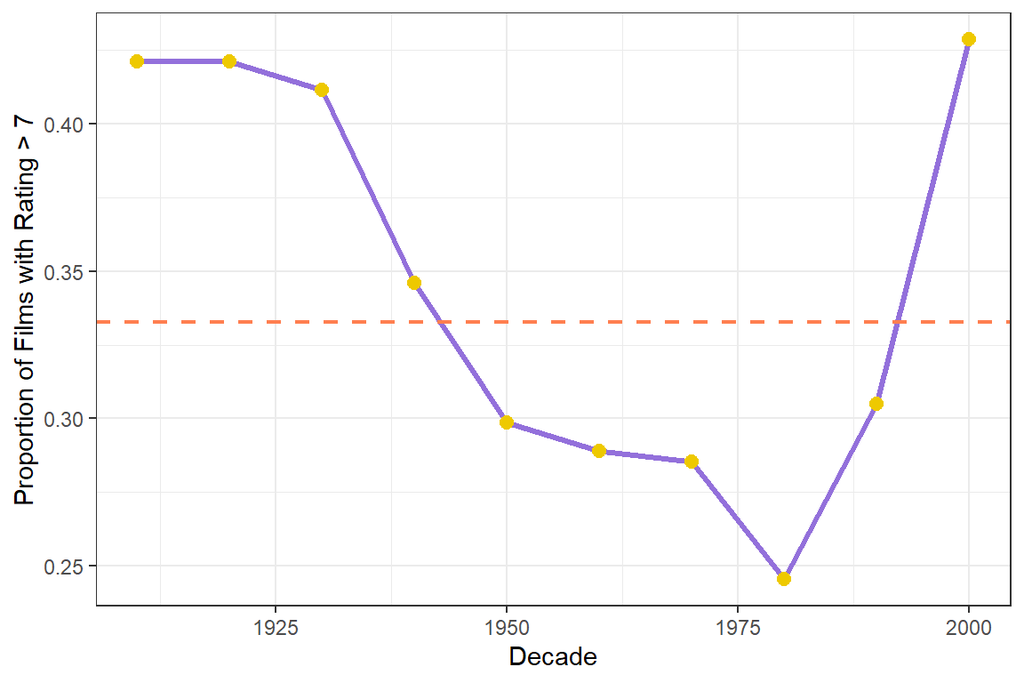

Figure 1: Proportion of Highly Rated Films by Release Decade

```r
# Create a dataset summarising high ratings by release decade
movies_year <- movies %>%
  filter(year >= 1910) %>%                     # Remove very early films with few observations
  mutate(decade = floor(year/10)*10) %>%       # Convert year into decade groups
  group_by(decade) %>%
  summarise(
    proportion_high = mean(high_rating, na.rm = TRUE), # Proportion of high ratings
    count = n()                                         # Number of films in each decade
  )

# Plot the proportion of high-rated films across decades
ggplot(movies_year, aes(x = decade, y = proportion_high)) +
  geom_line(colour = "mediumpurple", linewidth = 1.2) +
  geom_point(colour = "gold2", size = 2.5) +
  geom_hline(yintercept = mean(movies$high_rating),     # Overall proportion reference line
             linetype = "dashed",
             colour = "coral",
             linewidth = 0.8) +
  labs(
    x = "Decade",
    y = "Proportion of Films with Rating > 7"
  ) +
  theme_bw()
```

Figure 1 shows the proportion of highly rated films across release decades. The dashed horizontal line represents the overall proportion of films with ratings above 7 in the dataset.

The proportion of highly rated films appears to vary across decades. Earlier decades tend to show somewhat higher proportions, while films released between the 1950s and 1980s appear to have relatively lower proportions. However, some early decades contain relatively few films, so these proportions should be interpreted with caution.

## 4.2 Film Length and IMDB Ratings

Film length may influence audience perception of a movie. To explore this relationship, film length is treated as a continuous variable and the relationship between film length and the probability of receiving a high rating is visualised using a logistic smoothing curve.

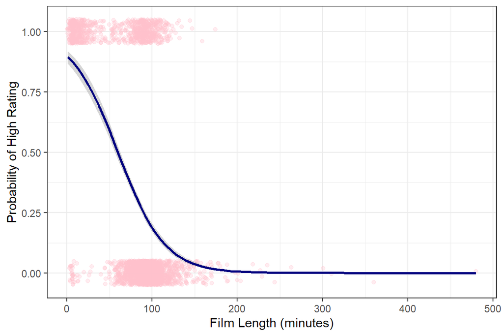

Figure 2: Relationship Between Film Length and the Probability of High IMDB Ratings

```r
# Remove observations with missing film length values
movies_length <- subset(movies, !is.na(length))

# Plot relationship between film length and probability of high rating
ggplot(movies_length, aes(x = length, y = high_rating)) +
  geom_jitter(height = 0.05, alpha = 0.3, colour = "pink") + # Scatter points with jitter
  geom_smooth(method = "glm",                                # Logistic regression smoothing
              method.args = list(family = "binomial"),
              colour = "navy") +
  labs(
    x = "Film Length (minutes)",
    y = "Probability of High Rating"
  ) +
  theme_bw()
```

Figure 2 shows the relationship between film length and the probability of receiving a high IMDB rating.

The probability of receiving a rating above 7 appears to be higher for shorter films and gradually decreases as film length increases. This suggests that film length may be associated with high ratings, although the pattern may partly reflect differences in genre composition across films of different lengths.

## 4.3 Production budget and IMDB Ratings

Film budget may also influence how audiences perceive a movie. To explore this possibility, the distribution of film budgets and their relationship with IMDB ratings were examined.

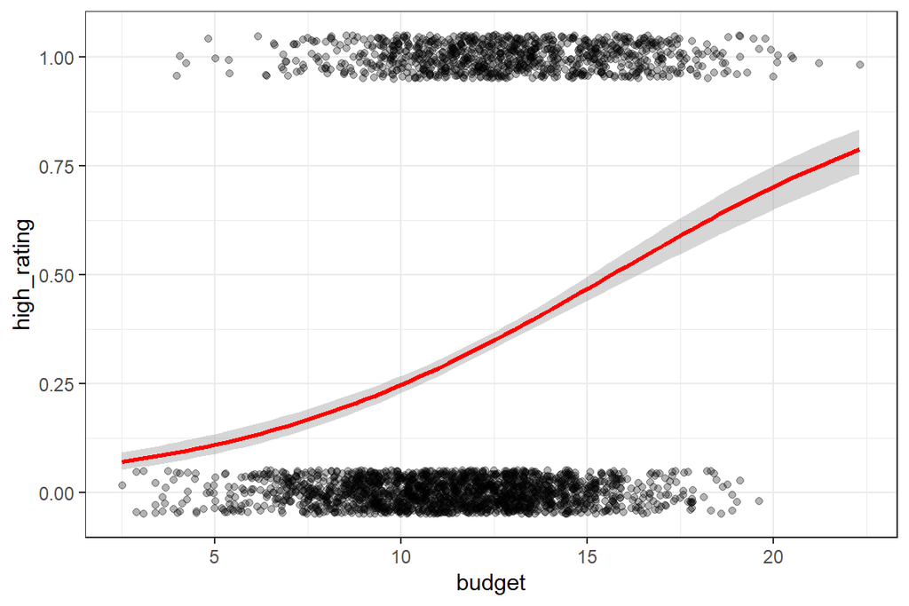

Figure 3: Relationship between film budget and the probability of receiving a high IMDB rating

```r
# Plot relationship between film budget and probability of high rating
ggplot(movies,
       aes(x = budget,
           y = high_rating)) +
  geom_jitter(height = 0.05, alpha = 0.3) +                  # Scatter points
  geom_smooth(
    method = "glm",                                          # Logistic smoothing curve
    method.args = list(family="binomial"),
    colour = "red"
  ) +
  theme_bw()
```

Figure 3 shows the relationship between film production budget and the probability of receiving a high IMDB rating. Each point represents an individual film, and the red curve corresponds to the fitted logistic regression line.

The fitted curve shows a gradual upward trend, suggesting that films with larger budgets may be somewhat more likely to receive high ratings. This suggests that budget may be positively associated with the likelihood of a film receiving a high rating.

## 4.4 Votes and High IMDB Ratings

The number of votes may reflect a film’s popularity or level of audience engagement. Since the distribution of votes is highly skewed, with some films receiving far more votes than others, direct comparisons using raw vote counts are difficult. Therefore, films were divided into five groups based on vote quantiles so that each group contains approximately the same number of observations. This grouping allows the proportion of highly rated films to be compared across different levels of audience engagement while reducing the influence of extreme vote counts.

The approximate vote ranges for the five groups are:  
Very Low: 5-10 votes  
Low: 10-20 votes  
Medium: 20-47 votes  
High: 47-174 votes  
Very High: above 174 votes.

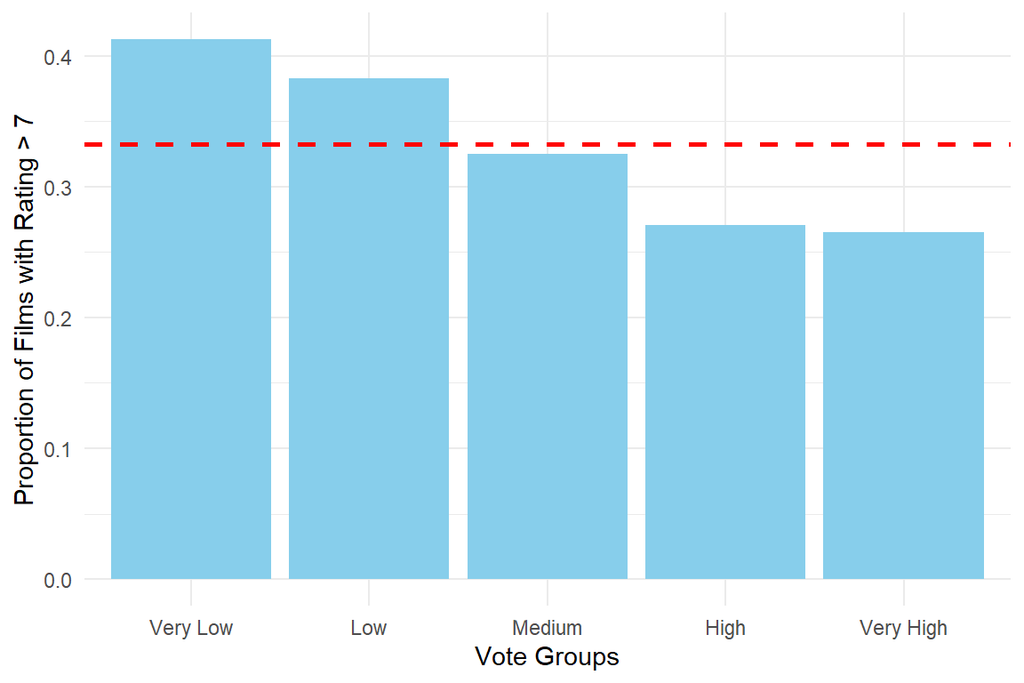

Figure 4: Proportion of High IMDB Ratings Across Vote Groups

```r
# Divide vote counts into five groups using quantiles
vote_breaks <- quantile(movies$votes, probs = seq(0,1,0.2), na.rm = TRUE)

# Create a categorical variable representing vote groups
movies$vote_group <- cut(
  movies$votes,
  breaks = vote_breaks,
  include.lowest = TRUE,
  labels = c("Very Low", "Low", "Medium", "High", "Very High")
)

# Calculate proportion of high ratings in each vote group
prop_table <- aggregate(high_rating ~ vote_group,
                        data = movies,
                        FUN = mean)

# Plot proportion of high ratings by vote group
ggplot(prop_table, aes(x = vote_group, y = high_rating)) +
  geom_bar(stat = "identity", fill = "skyblue") +
  geom_hline(yintercept = mean(movies$high_rating), # Overall proportion
             colour = "red",
             linetype = "dashed",
             linewidth = 1) +
  labs(
    x = "Vote Groups",
    y = "Proportion of Films with Rating > 7"
  ) +
  theme_minimal()
```

Figure 4 shows the proportion of highly rated films across vote groups. The dashed horizontal line represents the overall proportion of films with ratings above 7 in the dataset.

The proportion of highly rated films appears to vary across vote groups, with lower-vote groups showing slightly higher proportions than higher-vote groups. Although the pattern is not especially strong, it suggests that the relationship between vote count and high ratings may not be straightforward.

## 4.5 Film Genre and High IMDB Ratings

Film genre may influence how movies are perceived by audiences. Different genres may attract different audiences and may vary in storytelling style, which could affect IMDB ratings.

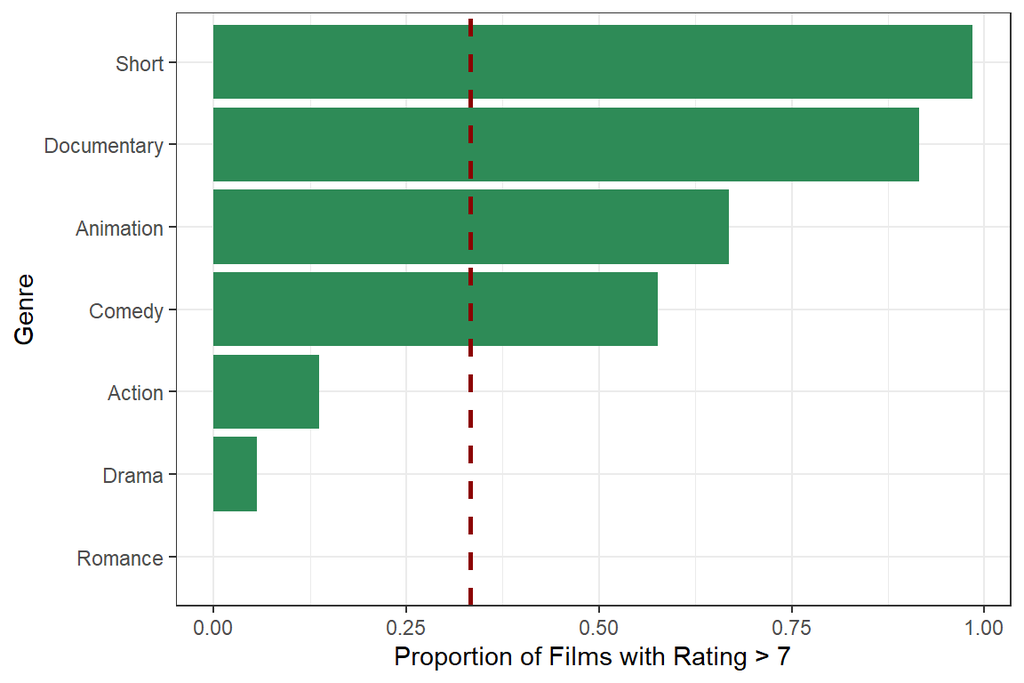

Figure 5: Proportion of Highly Rated Films by Genre

```r
# Calculate proportion of highly rated films for each genre
genre_prop <- movies %>%
  group_by(genre) %>%
  summarise(
    proportion_high = mean(high_rating, na.rm = TRUE),
    count = n()
  )

# Plot high rating proportion by genre
ggplot(genre_prop,
       aes(x = reorder(genre, proportion_high),
           y = proportion_high)) +
  geom_col(fill = "seagreen") +
  geom_hline(yintercept = mean(movies$high_rating, na.rm = TRUE), # Overall proportion
             colour = "darkred",
             linetype = "dashed",
             linewidth = 1) +
  coord_flip() +
  labs(
    x = "Genre",
    y = "Proportion of Films with Rating > 7"
  ) +
  theme_bw()
```

Figure 5 shows substantial variation in the proportion of highly rated films across genres. Some genres have much higher proportions of films with ratings above 7 than others.

This suggests that genre may be an important predictor of high ratings. However, some genres contain relatively few observations, so the corresponding proportions may be less stable and should be interpreted cautiously.

# 5 Model Fitting

## 5.1 Data Preprocessing

Before fitting the logistic regression models, a modelling dataset was created by selecting the variables required for the analysis and removing observations with missing values. In this analysis, the response variable is high_rating, while the candidate predictors are release year, film length, production budget, number of votes, and genre.

```r
# Create modelling dataset by selecting relevant variables
movies_model <- movies %>%
  select(high_rating, year, length, budget, votes, genre) %>%
  na.omit()   # Remove rows with any missing values

# Convert genre into a categorical variable
movies_model$genre <- factor(movies_model$genre)
```

The raw distribution of film genres was previously presented in Table 2, and the proportion of highly rated films across genres was illustrated in Figure 5. However, the logistic regression model uses the complete dataset after removing rows with missing values. Therefore, the reference category for genre should be chosen based on the final modelling sample rather than the raw dataset.

To assess which genre is most suitable as the reference category, the distribution of the binary outcome variable (high_rating) across genres is examined in the modelling dataset.

```r
# Summarise the outcome distribution for each genre in the modelling dataset
genre_outcome_model <- movies_model %>%
  group_by(genre) %>%
  summarise(
    n = n(),  # n = total number of films in the genre
    high_rating_0 = sum(high_rating == 0),  # high_rating_0 = number of films with rating <= 7
    high_rating_1 = sum(high_rating == 1),  # high_rating_1 = number of films with rating > 7
    prop_high = mean(high_rating)  # prop_high = proportion of films with rating > 7
  ) %>%
  arrange(desc(n))


# Display the summary table
kable(genre_outcome_model, digits = 3)
```

Table 4: Distribution of high ratings across genres in the modelling dataset

| genre | n | high_rating_0 | high_rating_1 | prop_high |
| --- | --- | --- | --- | --- |
| Action | 826 | 709 | 117 | 0.142 |
| Drama | 761 | 719 | 42 | 0.055 |
| Comedy | 647 | 276 | 371 | 0.573 |
| Animation | 174 | 56 | 118 | 0.678 |
| Documentary | 149 | 11 | 138 | 0.926 |
| Short | 131 | 2 | 129 | 0.985 |
| Romance | 28 | 28 | 0 | 0.000 |

Table 4 shows that the genre categories differ significantly in both sample size and outcome distribution. Action has the largest number of observations in the modelling dataset, which makes it a stable category for comparison. In addition, Action contains both low-rated and high-rated films, rather than being concentrated almost entirely in one outcome group.

Some genres exhibit much more extreme outcome distributions. For example, Romance contains no films with ratings above 7, while Short and Documentary are heavily concentrated in the high-rating group. Among the remaining genres, Drama is strongly skewed towards low-rated films, whereas Comedy and Animation are relatively more concentrated in higher ratings. Compared with these categories, Action represents a more moderate and less extreme distribution.

To visualise these differences more clearly, Figure 6 shows the proportion of low-rated and high-rated films within each genre.

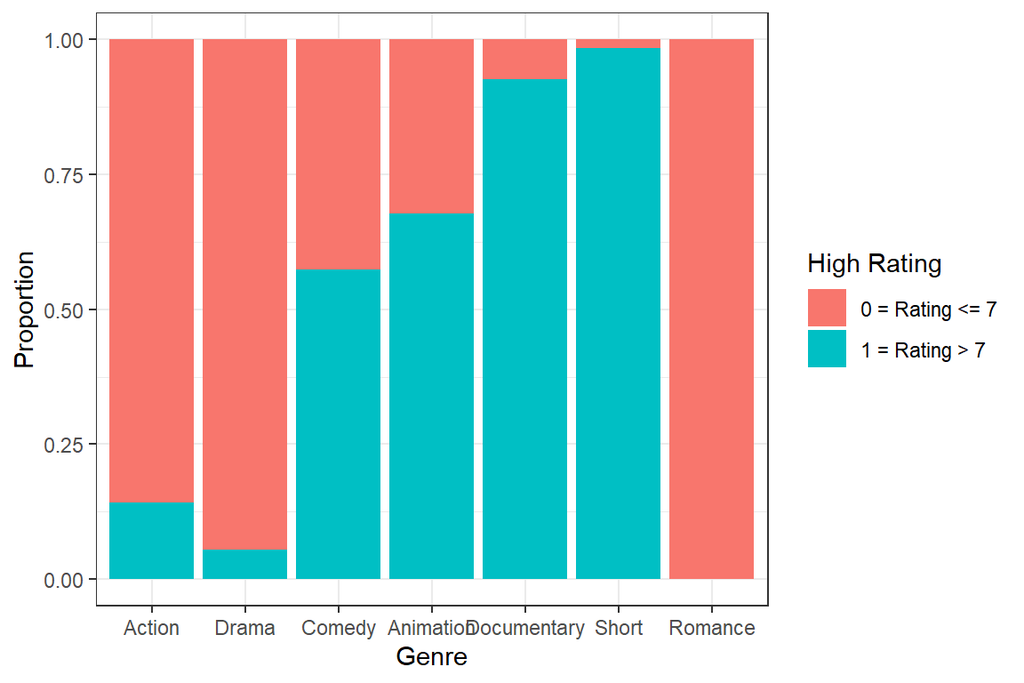

Figure 6: Proportion of low-rated and high-rated films within each genre in the modelling dataset

```r
# Create a proportional bar chart to show the composition of high_rating within each genre
ggplot(movies_model,
       aes(x = reorder(genre, -table(genre)[genre]), fill = factor(high_rating))) +
  geom_bar(position = "fill") +   # Show proportions instead of counts
  labs(
    x = "Genre",
    y = "Proportion",
    fill = "High Rating"
  ) +
  scale_fill_discrete(
    labels = c("0 = Rating <= 7", "1 = Rating > 7")
  ) +
  theme_bw()
```

For these reasons, Action was selected as the reference category for genre. This choice is supported by three aspects: it remains the largest genre in the modelling dataset, it provides a relatively stable baseline, and it allows for meaningful comparisons across genres.

```r
# Set Action as the reference category for genre
movies_model$genre <- relevel(movies_model$genre, ref = "Action")
```

After preprocessing, the modelling dataset is ready for logistic regression analysis, with genre coded as a categorical variable and Action defined as the baseline category for comparison.

## 5.2 Fitting Full Model

After data preprocessing, a full logistic regression model was fitted to investigate how film characteristics are associated with the probability of receiving a high IMDB rating.

In this analysis, the response variable is binary. Let $Y_i$ be the binary response for film $i$, where $Y_i = 1$ if the film has an IMDB rating above 7 and $Y_i = 0$ otherwise. Let $p_i = P(Y_i = 1)$ denote the probability that film $i$ receives a high IMDB rating. Since the response variable is binary, logistic regression with a logit link is used.

The full model can be written as

$$\text{logit}(p_i)=\log\left(\frac{p_i}{1-p_i}\right)
= \beta_0 + \beta_1 \text{year}_i + \beta_2 \text{length}_i + \beta_3 \text{budget}_i + \beta_4 \text{votes}_i + \text{genre effect}_i$$

where:

- $\beta_0$ is the intercept term for the reference genre;
- $\beta_1$ is the coefficient for release year;
- $\beta_2$ is the coefficient for film length;
- $\beta_3$ is the coefficient for production budget;
- $\beta_4$ is the coefficient for the number of votes;
- $\text{genre effect}_i$ represents the set of genre indicator terms, with each genre coefficient interpreted relative to the reference genre;
- $p_i$ is the probability that film $i$ receives a high IMDB rating;
- $\text{logit}(p_i)=\log\left(\frac{p_i}{1-p_i}\right)$ is the logit transformation, that is, the logarithm of the odds.

The logit transformation is appropriate because the response variable is binary. Rather than modelling the probability directly, logistic regression models the log-odds of receiving a high rating as a linear combination of the predictors. A positive regression coefficient indicates that the corresponding predictor increases the log-odds, and hence the probability, of a film receiving a high rating, while a negative coefficient indicates the opposite.

```r
# Fit the full logistic regression model
model_full <- glm(
  high_rating ~ year + length + budget + votes + genre,
  data = movies_model,
  family = binomial
)


# Display model results in a formatted table
tidy(model_full) %>%
  kable(
    digits = 3,
    col.names = c("Variable", "Estimate", "Std Error", "z value", "p value"),
    caption = "Logistic regression results (full model)"
  )
```

Table 5: Logistic regression results (full model)

| Variable | Estimate | Std Error | z value | p value |
| --- | --- | --- | --- | --- |
| (Intercept) | -23.616 | 5.789 | -4.079 | 0.000 |
| year | 0.010 | 0.003 | 3.429 | 0.001 |
| length | -0.057 | 0.004 | -16.003 | 0.000 |
| budget | 0.510 | 0.030 | 16.935 | 0.000 |
| votes | 0.000 | 0.000 | 0.508 | 0.612 |
| genreAnimation | -0.089 | 0.321 | -0.277 | 0.782 |
| genreComedy | 3.109 | 0.179 | 17.351 | 0.000 |
| genreDocumentary | 5.608 | 0.443 | 12.661 | 0.000 |
| genreDrama | -1.557 | 0.239 | -6.506 | 0.000 |
| genreRomance | -14.604 | 391.708 | -0.037 | 0.970 |
| genreShort | 4.002 | 0.797 | 5.021 | 0.000 |

The coefficient estimates for the full model are presented in Table 5. Statistical significance is assessed at the 5% level throughout the analysis, so predictors with p-values below 0.05 are regarded as statistically significant. The results show that votes is not statistically significant, suggesting that it does not provide strong evidence of an independent contribution once the other variables are included in the model.

Compared with this, year, length, budget, and several genre categories show statistically significant associations with the odds of receiving a high rating. Overall, the full model suggests that more recent films and films with larger production budgets tend to have higher odds of receiving an IMDB rating above 7, while longer films tend to have lower odds. In addition, the estimated genre effects indicate that the probability of receiving a high rating differs across film genres. These findings provide the basis for considering a simpler model that excludes the non-significant predictor votes.

## 5.3 Fitting Reduced Model

Since votes was not statistically significant in the full model, a reduced logistic regression model was fitted after removing this variable. The purpose of removing this variable is to examine whether the model can be improved after excluding votes.

The reduced model can be written as

$$\text{logit}(p_i)=\log\left(\frac{p_i}{1-p_i}\right)
= \beta_0 + \beta_1 \text{year}_i + \beta_2 \text{length}_i + \beta_3 \text{budget}_i + \text{genre effect}_i$$

where:

- $\beta_0$ is the intercept term for the reference genre;
- $\beta_1$ is the coefficient for release year;
- $\beta_2$ is the coefficient for film length;
- $\beta_3$ is the coefficient for production budget;
- $\text{genre effect}_i$ represents the set of genre indicator terms, with each genre coefficient interpreted relative to the reference genre;
- $p_i$ is the probability that film $i$ receives a high IMDB rating;
- $\text{logit}(p_i)=\log\left(\frac{p_i}{1-p_i}\right)$ is the logit transformation, that is, the logarithm of the odds.

Thus, the reduced model retains the key explanatory variables from the full model while excluding the non-significant predictor votes.

```r
# Fit reduced model excluding votes
model_reduced <- glm(
  high_rating ~ year + length + budget + genre,
  data = movies_model,
  family = binomial
)

# Display reduced model results
tidy(model_reduced) %>%
  kable(
    digits = 3,
    col.names = c("Variable", "Estimate", "Std Error", "z value", "p value"),
    caption = "Logistic regression results (reduced model)"
  )
```

Table 6: Logistic regression results (reduced model)

| Variable | Estimate | Std Error | z value | p value |
| --- | --- | --- | --- | --- |
| (Intercept) | -23.864 | 5.767 | -4.138 | 0.000 |
| year | 0.010 | 0.003 | 3.483 | 0.000 |
| length | -0.057 | 0.004 | -16.077 | 0.000 |
| budget | 0.510 | 0.030 | 16.933 | 0.000 |
| genreAnimation | -0.079 | 0.320 | -0.246 | 0.806 |
| genreComedy | 3.111 | 0.179 | 17.362 | 0.000 |
| genreDocumentary | 5.605 | 0.442 | 12.673 | 0.000 |
| genreDrama | -1.557 | 0.239 | -6.509 | 0.000 |
| genreRomance | -14.608 | 391.829 | -0.037 | 0.970 |
| genreShort | 4.006 | 0.797 | 5.028 | 0.000 |

The coefficient estimates for the reduced model are presented in Table 6. The results show that, after removing votes, the main predictors in the model remain statistically significant at the 5% level. In particular, year and budget still have positive estimated effects, while length still has a negative estimated effect.

The genre coefficients also continue to show differences between genres in their association with high IMDB ratings. Compared with the full model, the overall pattern of results remains stable after excluding votes. This suggests that votes contributes little to the model, and that the reduced model is still able to capture the main relationships between film characteristics and the probability of receiving a high rating.

## 5.4 Model comparison

### 5.4.1 Coefficient Comparison Table

To compare the full and reduced models, the estimated coefficients are presented side by side in Table 7.

```r
# Extract coefficients from full model
full_coef <- tidy(model_full) %>%
  select(term, estimate) %>%
  rename(Full_Model = estimate)

# Extract coefficients from reduced model
reduced_coef <- tidy(model_reduced) %>%
  select(term, estimate) %>%
  rename(Reduced_Model = estimate)

# Combine results into a comparison table
comparison <- full_coef %>%
  full_join(reduced_coef, by = "term")

# Display comparison table
kable(
  comparison,
  digits = 3,
  col.names = c("Predictor", "Full Model", "Reduced Model"),
  caption = "Comparison of coefficients between full and reduced models"
)
```

Table 7: Comparison of coefficients between full and reduced models

| Predictor | Full Model | Reduced Model |
| --- | --- | --- |
| (Intercept) | -23.616 | -23.864 |
| year | 0.010 | 0.010 |
| length | -0.057 | -0.057 |
| budget | 0.510 | 0.510 |
| votes | 0.000 | NA |
| genreAnimation | -0.089 | -0.079 |
| genreComedy | 3.109 | 3.111 |
| genreDocumentary | 5.608 | 5.605 |
| genreDrama | -1.557 | -1.557 |
| genreRomance | -14.604 | -14.608 |
| genreShort | 4.002 | 4.006 |

As shown in Table 7, removing the non-significant variable votes leads to only negligible changes in the estimated coefficients of the remaining predictors. In particular, the coefficients for release year, film length, production budget, and the genre categories remain very similar in magnitude and direction across the two models. This indicates that excluding votes has little impact on the estimated relationships between the other predictors and the probability of receiving a high IMDB rating.

### 5.4.2 Model Fitting Statistics Table

```r
# Create a summary table of model fit statistics
# AIC is used to compare model fit while accounting for model complexity
# Residual deviance and residual degrees of freedom are also reported
model_fit <- tibble(
  Model = c("Full model", "Reduced model"),
  AIC = c(AIC(model_full), AIC(model_reduced)),
  Residual_Deviance = c(deviance(model_full), deviance(model_reduced)),
  DF = c(df.residual(model_full), df.residual(model_reduced))
)


# Display the model fit statistics table
kable(
  model_fit,
  digits = 3,
  caption = "Model fit statistics for the full and reduced models"
)
```

Table 8: Model fit statistics for the full and reduced models

| Model | AIC | Residual_Deviance | DF |
| --- | --- | --- | --- |
| Full model | 1478.365 | 1456.365 | 2705 |
| Reduced model | 1476.593 | 1456.593 | 2706 |

The model fitting statistics for the full and reduced models are presented in Table 8. The reduced model has a slightly lower AIC than the full model, which indicates a better balance between model fit and model complexity. Although the residual deviance of the reduced model is marginally higher than that of the full model, the difference is negligible. This indicates that removing the variable votes leads to almost no loss of explanatory power while producing a simpler model.

## 5.5 Final Model Selection

In the full model, the coefficient for the number of votes was not statistically significant. After removing this variable, the reduced model produced a slightly lower AIC and almost the same residual deviance as the full model. In addition, the comparison of coefficients between the two models showed that the estimated effects of the remaining predictors changed very little after excluding votes. Therefore, the reduced model was selected as the final model because it achieves a slight improvement in overall model performance while maintaining a very similar level of fit, and provides a more parsimonious representation of the data.

The final selected model is:

$$\text{logit}(p_i)=\log\left(\frac{p_i}{1-p_i}\right)
= \beta_0 + \beta_1 \text{year}_i + \beta_2 \text{length}_i + \beta_3 \text{budget}_i + \text{genre effect}_i$$

where:

- $\beta_0$ is the intercept term for the reference genre;
- $\beta_1$ is the coefficient for release year;
- $\beta_2$ is the coefficient for film length;
- $\beta_3$ is the coefficient for production budget;
- $\text{genre effect}_i$ represents the set of genre indicator terms, with each genre coefficient interpreted relative to the reference genre;
- $p_i$ is the probability that film $i$ receives a high IMDB rating;
- $\text{logit}(p_i)=\log\left(\frac{p_i}{1-p_i}\right)$ is the logit transformation, that is, the logarithm of the odds.

## 5.6 Odds Ratios of the Final Model

```r
# Convert logistic regression coefficients to odds ratios
or_reduced <- tidy(model_reduced, conf.int = TRUE) %>%
  mutate(
    OR = exp(estimate),       # Odds ratio
    CI_low = exp(conf.low),   # Lower confidence interval
    CI_high = exp(conf.high)  # Upper confidence interval
  ) %>%
  select(term, OR, std.error, statistic, p.value, CI_low, CI_high)

# Display odds ratio table
kable(
  or_reduced,
  digits = 3,
  col.names = c("Predictor", "OR", "SE", "z", "p", "CI low", "CI high"),
  caption = "Odds ratios for the reduced logistic regression model"
)
```

Table 9: Odds ratios for the reduced logistic regression model

| Predictor | OR | SE | z | p | CI low | CI high |
| --- | --- | --- | --- | --- | --- | --- |
| (Intercept) | 0.000 | 5.767 | -4.138 | 0.000 | 0.000 | 0.000 |
| year | 1.010 | 0.003 | 3.483 | 0.000 | 1.005 | 1.016 |
| length | 0.945 | 0.004 | -16.077 | 0.000 | 0.938 | 0.951 |
| budget | 1.665 | 0.030 | 16.933 | 0.000 | 1.572 | 1.769 |
| genreAnimation | 0.924 | 0.320 | -0.246 | 0.806 | 0.491 | 1.725 |
| genreComedy | 22.439 | 0.179 | 17.362 | 0.000 | 15.905 | 32.119 |
| genreDocumentary | 271.756 | 0.442 | 12.673 | 0.000 | 119.805 | 683.371 |
| genreDrama | 0.211 | 0.239 | -6.509 | 0.000 | 0.130 | 0.333 |
| genreRomance | 0.000 | 391.829 | -0.037 | 0.970 | 0.000 | 207.390 |
| genreShort | 54.903 | 0.797 | 5.028 | 0.000 | 14.173 | 370.971 |

Table 9 presents the odds ratios from the final logistic regression model. The odds ratios are obtained by exponentiating the estimated coefficients and provide an interpretable measure of how each predictor affects the odds that a film receives an IMDB rating above 7, holding the other variables constant.

## 5.7 Predicted Probabilities

To further illustrate the final logistic regression model, predicted probabilities were calculated using the reduced model. Film length was allowed to vary across its observed range, while release year and production budget were held constant at their mean values.

Predicted probabilities were generated for several selected genres in order to visualise how the probability of receiving an IMDB rating above 7 changes with film length and genre.

For classification purposes, a default cutoff value of 0.5 was also specified in the prediction code. This means that a film would be classified as predicted high rating if its predicted probability is greater than 0.5, and as not high rating otherwise.

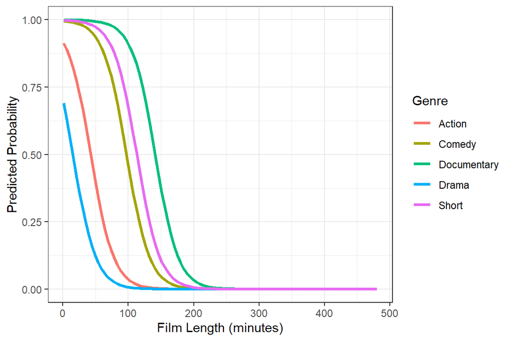

Figure 7: Predicted Probability of High IMDB Rating by Film Length and Genre

```r
# Create new dataset for prediction
newdata <- expand.grid(
  length = seq(
    min(movies_model$length, na.rm = TRUE),
    max(movies_model$length, na.rm = TRUE),
    length.out = 100
  ),
  year = mean(movies_model$year, na.rm = TRUE),   # Fix year at mean value
  budget = mean(movies_model$budget, na.rm = TRUE), # Fix budget at mean value
  genre = c("Action", "Comedy", "Documentary", "Drama", "Short") # Selected genres
)

# Generate predicted probabilities from the reduced model
newdata$pred_prob <- predict(
  model_reduced,
  newdata = newdata,
  type = "response"
)

# Set classification rule
cutoff <- 0.5
newdata$pred_class <- ifelse(newdata$pred_prob > cutoff, 1, 0)

# Plot predicted probabilities
ggplot(newdata, aes(x = length, y = pred_prob, colour = genre)) +
  geom_line(linewidth = 1.2) +
  labs(
    x = "Film Length (minutes)",
    y = "Predicted Probability",
    colour = "Genre"
  ) +
  theme_bw()
```

Figure 7 shows the predicted probability that a film receives an IMDB rating above 7 across different film lengths for several selected genres.

The predicted probabilities decrease as film length increases, indicating that longer films are generally less likely to receive ratings above 7 according to the fitted model. This pattern is consistent with the negative coefficient of film length observed in the logistic regression results.

Differences between genres can be clearly seen. Documentary films consistently have the highest probability of receiving a rating above 7 across most film lengths, with Short films also showing relatively high probabilities. Comedy films show moderate probabilities, followed by Action films. Meanwhile, Drama films have the lowest probability of receiving a rating above 7 across the range of film lengths considered.

Overall, the figure illustrates how the final logistic regression model combines the effects of film length and genre to predict the probability that a film achieves an IMDB rating above 7, while holding the other predictors constant.

# 6 Model Limitation

This analysis has several limitations that should be taken into account when interpreting the results.

First, the dataset contains only a limited number of film characteristics, including release year, film length, production budget, number of votes, and genre. Other potentially important factors, such as director, cast, country of production, awards, marketing exposure, or distribution platform, are not included. As a result, the fitted model may omit variables that also influence whether a film receives an IMDB rating above 7.

Second, missing values in film length were handled by removing incomplete observations before model fitting. Although this produces a simple and consistent modelling dataset, it reduces the sample size and may introduce bias if the missing values are not completely random.

Third, some genres contain relatively small numbers of films compared with the larger categories. This may lead to less stable coefficient estimates for those smaller groups, so the corresponding genre effects should be interpreted with caution.

Finally, the analysis is based on a binary transformation of the original IMDB rating. While this makes logistic regression suitable and allows a clear distinction between high-rated and non-high-rated films, it also simplifies the original rating scale and may lose some information contained in the full range of ratings.

# 7 Future Work

There are several ways in which this analysis could be extended in future work.

First, more explanatory variables could be added to the model. Including information such as director, actors, awards, country of production, or distribution platform may provide a more complete understanding of the factors associated with high IMDB ratings.

Second, alternative approaches to handling missing data could be considered. Instead of removing incomplete observations, future analysis could explore imputation methods and compare whether the results remain consistent.

Third, the current analysis focuses on main effects only. Future work could investigate whether interaction effects are present. For example, the relationship between film length and rating may differ across genres, or the effect of budget may vary across release periods.

# 8 Conclusion

This analysis examined which film characteristics are associated with whether a film receives an IMDB rating greater than 7. To answer this question, a binary response variable was created to distinguish films with ratings above 7 from those with ratings of 7 or below, and logistic regression was used to model the probability of receiving a high rating.

A full model including release year, film length, production budget, number of votes, and genre was first fitted. Since the number of votes was not statistically significant, a reduced model excluding this variable was selected as the final model. The reduced model achieved a slightly lower AIC than the full model, while the estimated effects of the remaining predictors stayed broadly similar. This suggests that removing votes improved the model slightly.

Overall, the final model indicates that release year, film length, production budget, and genre are important predictors of whether a film receives an IMDB rating above 7. In particular, more recent films and films with larger production budgets tend to have higher odds of receiving a high rating, while longer films tend to have lower odds. Differences across genres were also evident, indicating that genre plays an important role in the probability of a film being highly rated.

In summary, these findings show that logistic regression provides a useful and interpretable framework for examining how film characteristics are associated with high IMDB ratings. Although the model does not capture every factor that may influence audience evaluation, it provides a clear statistical summary of the main relationships in this dataset.